# Association Rules Practice

Dennis Tseng, 2018/06/23

This project is my trial to apply association rules to the real-world data. There are many precious tutorials and one of them not only talk about abstract concepts but also practical application of `arules` package in R. [The article](https://cran.r-project.org/web/packages/arules/vignettes/arules.pdf) is on CRAN. Besides, I use data from [here](https://github.com/nupur1492/RProjects/blob/master/MarketBasketAnalysis/groceries.csv). The data is bundled with a tutorial, though there are many mistakes in that article. Thus, I give up and try to understand and practice association rulses on my own. Hope it works!

```r
library(tidyverse)
library(arules)
library(arulesViz)
library(knitr)
library(kableExtra)
rm(list=ls())
df <- read_csv("D:/R_programming/DSprogramming/groceries.csv",
               col_types = cols(
                 Member_number = col_character(),
                 Date = col_date("%m/%d/%Y"),
                 itemDescription = col_character()))
names(df) <- c("member_ID", "date", "item")
```

Let’s take a look at the data!

```r
glimpse(df)
```

```
## Observations: 260
## Variables: 3
## $ member_ID <chr> "1.61905E+12", "1.67903E+12", "1.63404E+12", "1.6560...
## $ date      <date> 2012-10-22, 2010-10-03, 2011-07-07, 2010-03-13, 201...
## $ item      <chr> "citrus fruit", "tropical fruit", "whole milk", "pip...
```

There are three columns of this grocery data, which are member_ID, date, and items bought. Each observation contains an item only, so if a customer buy 5 items in the same time, it will account for 5 observations. Now I am goint to use `group_by` to check the real number of transaction.

```r
df %>% group_by(member_ID, date) %>%
  count(sort = T)
```

```
## # A tibble: 199 x 3
## # Groups:   member_ID, date [199]
##    member_ID   date           n
##    <chr>       <date>     <int>
##  1 1.61607E+12 2012-12-30     7
##  2 1.61201E+12 2013-09-07     6
##  3 1.69201E+12 2011-01-30     6
##  4 1.60604E+12 2010-08-19     4
##  5 1.61103E+12 2012-12-03     4
##  6 1.61708E+12 2014-11-23     4
##  7 1.62604E+12 2010-01-17     4
##  8 1.62609E+12 2010-07-20     4
##  9 1.63005E+12 2012-10-22     4
## 10 1.65111E+12 2013-11-15     4
## # ... with 189 more rows
```

`arules` needs a primary key, but primary key in `df` is composite key. I convert it below. `group_id` is the new single primary key of `df2`. We can take a look at `glimpse(df2)` and `df2 %>% group_by(group_id) %>% count(sort = T) %>% glimpse()`

```r
df2 <- df %>%
  unite(gawy, c(member_ID, date), sep = "-")
df2$group_id <- df2 %>% group_indices(gawy)
df2$gawy <- NULL
df2 <- df2 %>% select(group_id, item) %>% arrange(group_id)
glimpse(df2)
```

```
## Observations: 260
## Variables: 2
## $ group_id <int> 1, 2, 3, 4, 5, 6, 7, 8, 9, 10, 11, 12, 13, 13, 13, 13...
## $ item     <chr> "newspapers", "shopping bags", "chewing gum", "bottle...
```

```r
df2 %>% group_by(group_id) %>% count(sort = T) %>% glimpse()
```

```
## Observations: 199
## Variables: 2
## $ group_id <int> 38, 27, 190, 13, 25, 39, 52, 53, 64, 113, 117, 119, 1...
## $ n        <int> 7, 6, 6, 4, 4, 4, 4, 4, 4, 4, 4, 4, 4, 4, 3, 3, 3, 3,...
```

After completing the transformation of df2, it is needed to use function in `arules` to continue.

```r
#write.csv(df2, "df2.csv") I have wrriten it.
order_trans <- read.transactions(
  file = "df2.csv",
  format = "single",
  sep = ",",
  cols=c("group_id","item"),
  rm.duplicates = T
)
length(order_trans)
```

```
## [1] 199
```

```r
dim(order_trans)
```

```
## [1] 199  73
```

```r
size(order_trans)
```

```
##   [1] 1 1 2 1 1 1 1 1 1 1 1 1 1 1 1 1 4 1 1 1 4 1 4 1 1 1 4 1 1 1 1 2 1 1 4
##  [36] 1 1 1 1 1 1 1 1 1 1 1 1 1 1 1 1 1 1 1 1 1 1 1 1 1 1 1 1 1 1 1 1 1 1 1
##  [71] 1 1 1 1 3 1 1 1 1 1 1 1 1 1 1 1 1 1 1 1 3 1 2 1 1 4 1 1 1 1 1 4 1 1 1
## [106] 1 1 1 1 1 1 1 1 1 1 1 1 4 1 6 1 1 1 1 1 1 1 1 1 3 1 7 4 1 1 1 1 1 1 1
## [141] 1 1 1 1 1 1 1 4 4 1 3 1 1 1 1 1 1 1 1 1 3 1 1 1 1 1 1 1 1 1 1 1 1 1 1
## [176] 1 1 1 1 1 1 1 2 1 1 1 1 1 1 1 1 1 1 1 1 1 1 1 1
```

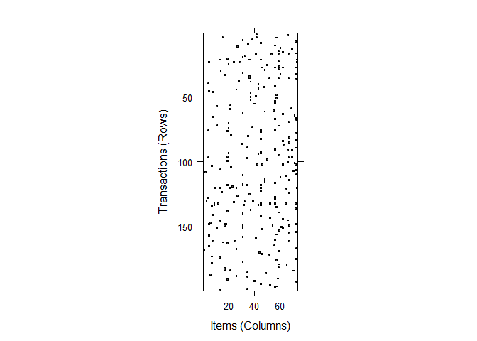

```r
image(order_trans)
```

```r
summary(order_trans)
```

```
## transactions as itemMatrix in sparse format with
##  199 rows (elements/itemsets/transactions) and
##  73 columns (items) and a density of 0.0176912
##
## most frequent items:
##       whole milk       rolls/buns other vegetables          sausage
##               20               15               14               13
##      frankfurter          (Other)
##               12              183
##
## element (itemset/transaction) length distribution:
## sizes
##   1   2   3   4   6   7
## 177   4   5  11   1   1
##
##    Min. 1st Qu.  Median    Mean 3rd Qu.    Max.
##   1.000   1.000   1.000   1.291   1.000   7.000
##
## includes extended item information - examples:
##             labels
## 1 abrasive cleaner
## 2    baking powder
## 3 bathroom cleaner
##
## includes extended transaction information - examples:
##   transactionID
## 1             1
## 2            10
## 3           100
```

`order_trans` is a specific data type in `arules` package. It is a sparse matrix consists of transactions as row and items as columns. If items appear in a transcation, the value will be 1, and 0 vice versa. `size(order_trans)` indicates items bought in each transcation. `image(order_trans)` gives us a broader look to the big picture. It is useful to check the condition such as whether some items are out of shelter.

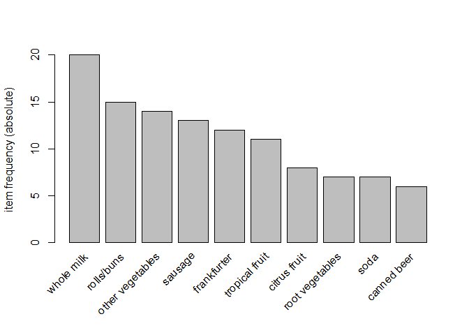

```r
itemFrequencyPlot(order_trans, topN=10,type="absolute")
```

We can take a look at the frequency plot. It is clear that whole milk is a hot item. So are rolls/buns.

```r
basket_rules <- apriori(order_trans, parameter = list(sup = 0.01, conf = 0.5,target="rules"))
```

```
## Apriori
##
## Parameter specification:
##  confidence minval smax arem  aval originalSupport maxtime support minlen
##         0.5    0.1    1 none FALSE            TRUE       5    0.01      1
##  maxlen target   ext
##      10  rules FALSE
##
## Algorithmic control:
##  filter tree heap memopt load sort verbose
##     0.1 TRUE TRUE  FALSE TRUE    2    TRUE
##
## Absolute minimum support count: 1
##
## set item appearances ...[0 item(s)] done [0.00s].
## set transactions ...[73 item(s), 199 transaction(s)] done [0.00s].
## sorting and recoding items ... [48 item(s)] done [0.00s].
## creating transaction tree ... done [0.00s].
## checking subsets of size 1 2 3 done [0.00s].
## writing ... [11 rule(s)] done [0.00s].
## creating S4 object  ... done [0.00s].
```

```r
rules <- sort(basket_rules, decreasing = TRUE, by = "confidence")
```

`apriori` is one of algorithm of association rules. Using `apriori` function, `order_trans` are transformed into `rules`, another specific data type related to association rules. Let’s take a look at it.

```r
inspect(rules)
```

```
##      lhs                                       rhs
## [1]  {brown bread}                          => {other vegetables}
## [2]  {packaged fruit/vegetables,soda}       => {whole milk}
## [3]  {packaged fruit/vegetables,whole milk} => {soda}
## [4]  {soda,whole milk}                      => {packaged fruit/vegetables}
## [5]  {canned beer,yogurt}                   => {other vegetables}
## [6]  {canned beer,other vegetables}         => {yogurt}
## [7]  {other vegetables,yogurt}              => {canned beer}
## [8]  {yogurt}                               => {canned beer}
## [9]  {yogurt}                               => {other vegetables}
## [10] {packaged fruit/vegetables}            => {soda}
## [11] {packaged fruit/vegetables}            => {whole milk}
##      support    confidence lift     count
## [1]  0.01005025 1.0000000  14.21429 2
## [2]  0.01005025 1.0000000   9.95000 2
## [3]  0.01005025 1.0000000  28.42857 2
## [4]  0.01005025 1.0000000  49.75000 2
## [5]  0.01005025 1.0000000  14.21429 2
## [6]  0.01005025 1.0000000  66.33333 2
## [7]  0.01005025 1.0000000  33.16667 2
## [8]  0.01005025 0.6666667  22.11111 2
## [9]  0.01005025 0.6666667   9.47619 2
## [10] 0.01005025 0.5000000  14.21429 2
## [11] 0.01005025 0.5000000   4.97500 2
```

```r
summary(rules)
```

```
## set of 11 rules
##
## rule length distribution (lhs + rhs):sizes
## 2 3
## 5 6
##
##    Min. 1st Qu.  Median    Mean 3rd Qu.    Max.
##   2.000   2.000   3.000   2.545   3.000   3.000
##
## summary of quality measures:
##     support          confidence          lift            count
##  Min.   :0.01005   Min.   :0.5000   Min.   : 4.975   Min.   :2
##  1st Qu.:0.01005   1st Qu.:0.6667   1st Qu.:12.082   1st Qu.:2
##  Median :0.01005   Median :1.0000   Median :14.214   Median :2
##  Mean   :0.01005   Mean   :0.8485   Mean   :24.258   Mean   :2
##  3rd Qu.:0.01005   3rd Qu.:1.0000   3rd Qu.:30.798   3rd Qu.:2
##  Max.   :0.01005   Max.   :1.0000   Max.   :66.333   Max.   :2
##
## mining info:
##         data ntransactions support confidence
##  order_trans           199    0.01        0.5
```

`rules` tell about the basic concept underling association rules. We can also check that in the plot form.

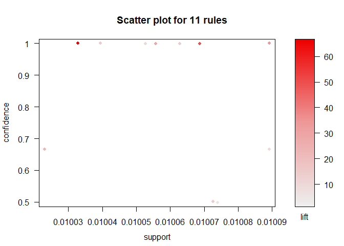

```r
plot(basket_rules)
```

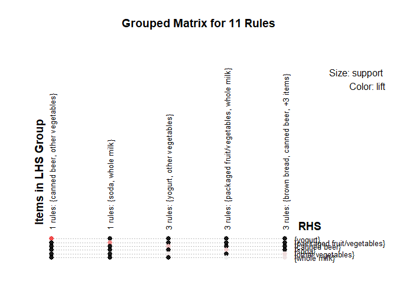

```r
plot(rules, method = "grouped", control = list(k = 5))
```

[output not shown]

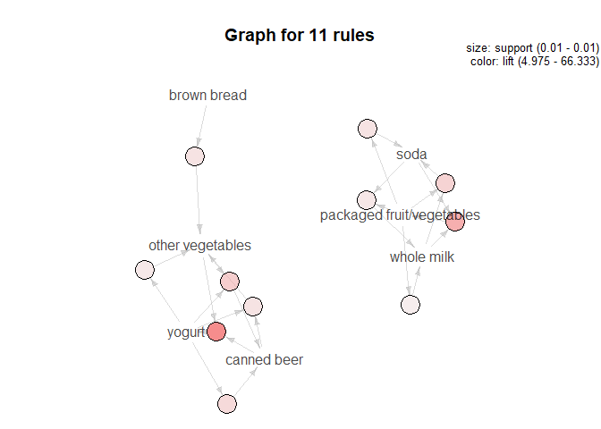

```r
plot(rules, method = "graph", control = list(type = "items"))
```

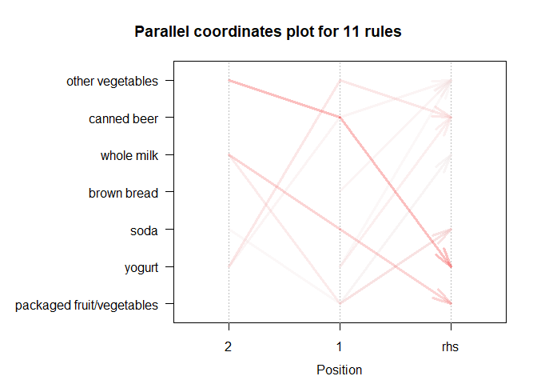

```r
plot(rules, method = "paracoord",  control = list(alpha = .5, reorder = TRUE))
```

To conclude, I applied the concepts learned and tried many useful packages such as `dplyr`, `arules` in this porject. I spent much time in understanding association rules and application in real life. I wish I could hand the real world data next time!